# Anàlisi estadística - PAC 3

## Autor: Adrià Santacreu i Giménez

Desembre 2024

## Taula de Continguts

### Preparació inicial de l’estudi

En aquest apartat, definim i carreguem tots els elements necessaris per a l’anàlisi que es mantindran constants durant tot l’estudi. Inclourem la càrrega de llibreries, la lectura del fitxer de dades inicial, i la definició de variables globals que utilitzarem en els diferents exercicis. D’aquesta manera, assegurem que totes les eines, dades i paràmetres constants estiguin disponibles i ben definits des del començament.

```r
knitr::opts_chunk$set(echo = TRUE)

# Definim un mirror per defecte
options(repos = c(CRAN = "https://cran.r-project.org"))

# Carreguem les llibreries necessàries
if (!require("dplyr")) install.packages("dplyr", dependencies = TRUE); library(dplyr)
if (!require("ggplot2")) install.packages("ggplot2", dependencies = TRUE); library(ggplot2)
if (!require("knitr")) install.packages("knitr", dependencies = TRUE); library(knitr)
if (!require("gridExtra")) install.packages("gridExtra", dependencies = TRUE); library(gridExtra)
if (!require("tidyr")) install.packages("tidyr", dependencies = TRUE); library(tidyr)
if (!require("car")) install.packages("car", dependencies = TRUE); library(car)
if (!require("caret")) install.packages("caret", dependencies = TRUE); library(caret)
if (!require("nnet")) install.packages("nnet", dependencies = TRUE); library(nnet)
if (!require("kableExtra")) install.packages("kableExtra", dependencies = TRUE); library(kableExtra)
if (!require("arules")) install.packages("arules", dependencies = TRUE); library(arules)

# Carreguem el fitxer de dades "Astronomy.csv"
data <- read.csv("Astronomy.csv")

# Vector de colors per a les categories de Tipo_Cat
tipo_cat_colors <- c(
  "Brown Dwarf" = "#8B4513",
  "Red Dwarf" = "#FF4500",
  "White Dwarf" = "#FFFFFF",
  "Main Sequence" = "#4682B4",
  "Supergiant" = "#FFD700",
  "Hypergiant" = "#FF6347"
)
```

Un cop carregades les llibreries, llegit el fitxer de dades, i definides les variables necessàries per a dur a terme aquest estudi, comencem amb la resolució dels exercicis.

### Descripció del conjunt de dades

El conjunt de dades proporcionat conté informació sobre diferents característiques físiques i classificacions d’estrelles. Cada fila representa una estrella, i les columnes detallen les seves propietats. Les variables incloses són:

1. **Temperatura**: La temperatura superficial de l’estrella, expressada en Kelvin ($K$).
2. **Luminosidad**: La lluminositat relativa de l’estrella respecte al Sol ($L/L_\odot$).
3. **Radio**: El radi relatiu de l’estrella respecte al Sol ($R/R_\odot$).
4. **Magnitud**: La magnitud absoluta de l’estrella, una mesura de la seva brillantor.
5. **Tipo_re**: Un codi numèric que classifica les estrelles segons tipus simplificats.
6. **Tipo_Cat**: La classificació de l’estrella segons categories astronòmiques, com ara “White Dwarf”, “Main Sequence”, “Supergiant”, etc.
7. **Color**: El color de l’estrella segons l’anàlisi espectral.
8. **Clase_Espectral**: La classe espectral basada en el sistema Morgan-Keenan, amb lletres que van de “O” (major temperatura) a “M” (menor temperatura).

A continuació, mostrem les primeres files del conjunt de dades per a tenir una visió general de la seva estructura.

```r
# Mostrem les primeres files del conjunt de dades
head(data)
```

```
##   Temperatura Luminosidad   Radio Magnitud Tipo_re      Tipo_Cat      Color
## 1        7740     0.00049 0.01234    14.02       2   White Dwarf      White
## 2        8500     0.00050 0.01000    14.50       2   White Dwarf      White
## 3        8570     0.00081 0.00970    14.20       2   White Dwarf Blue white
## 4        8052     8.70000 1.80000     2.42       3 Main Sequence    Whitish
## 5        8930     0.00056 0.00950    13.78       2   White Dwarf      white
## 6        9675     0.00045 0.01090    13.98       2   White Dwarf Blue White
##   Clase_Espectral
## 1               A
## 2               A
## 3               A
## 4               A
## 5               A
## 6               A
```

### Exercici 1.1 [10%]

#### Exercici 1.1.1

**Calculeu la matriu de correlació lineal entre totes les variables quantitatives de la base de dades. Interpreteu.**

En aquesta primera part de l’exercici 1.1, analitzarem la relació entre les variables quantitatives del conjunt de dades mitjançant una matriu de correlació. Aquesta ens permetrà identificar possibles associacions lineals entre les variables `Temperatura`, `Luminosidad`, `Radio` i `Magnitud`. La interpretació dels coeficients de correlació ens ajudarà a entendre si aquestes variables estan positivament o negativament relacionades i amb quina intensitat.

```r
# Calculem la matriu de correlació per a les variables quantitatives
numeric_vars <- data %>%
  select(Temperatura, Luminosidad, Radio, Magnitud)

# Generem la matriu de correlació
cor_matrix <- cor(numeric_vars, use = "complete.obs")

# Mostrem la matriu
kable(cor_matrix, caption = "Matriu de correlació entre variables quantitatives") %>%
  kable_styling(full_width = FALSE, position = "center", bootstrap_options = c("striped", "hover")) %>%
  row_spec(0, background = "#333333", color = "white") %>%
  row_spec(1:nrow(cor_matrix), color = "white", background = "#444444") %>%
  column_spec(1:ncol(cor_matrix), color = "white")
```

Matriu de correlació entre variables quantitatives

|  | Temperatura | Luminosidad | Radio | Magnitud |
| --- | --- | --- | --- | --- |
| Temperatura | 1.0000000 | 0.3934041 | 0.0642160 | -0.4202605 |
| Luminosidad | 0.3934041 | 1.0000000 | 0.5265157 | -0.6926192 |
| Radio | 0.0642160 | 0.5265157 | 1.0000000 | -0.6087282 |
| Magnitud | -0.4202605 | -0.6926192 | -0.6087282 | 1.0000000 |

##### Valoració dels resultats de la matriu de correlació

1. **Temperatura i Luminositat**: La correlació de $0.39$ indica una associació positiva moderada, suggerint que estrelles amb temperatures més altes tendeixen a tenir una major lluminositat.
2. **Temperatura i Radi**: La correlació de $0.06$ és molt baixa, suggerint que no hi ha una relació significativa entre aquestes dues variables.
3. **Temperatura i Magnitud**: La correlació de $-0.42$ mostra una relació negativa moderada, indicant que les estrelles amb temperatures més altes tendeixen a tenir magnituds absolutes més baixes (més brillants).
4. **Luminositat i Radi**: La correlació de $0.53$ és moderada, suggerint que estrelles més lluminoses solen tenir un radi més gran.
5. **Luminositat i Magnitud**: La correlació de $-0.69$ indica una forta relació negativa, evidenciant que estrelles amb major lluminositat tenen magnituds absolutes més baixes.
6. **Radi i Magnitud**: La correlació de $-0.61$ mostra una relació negativa moderada-forta, suggerint que les estrelles amb un radi més gran solen tenir magnituds absolutes més baixes.

#### Exercici 1.1.2

**Calculeu el gràfic de dispersió entre la `Temperatura` i la `Magnitud` de les estrelles. Aquest gràfic seria una representació senzilla d’un diagrama molt famós utilitzat en Astronomia, denominat diagrama de Hertzsprung-Russell (HR diagram). Per a una millor representació d’aquest, es demana agrupar els punts plotejats en el gràfic segons la variable categòrica `Tipo_Cat`, utilitzant un color distint per a cadascun dels tipus d’estrelles. Interpreteu el gràfic obtingut.**

En aquesta segona part de l’exercici 1.1, generarem un diagrama de Hertzsprung-Russell (HR) per representar la relació entre la temperatura i la magnitud de les estrelles. Aquest diagrama és una eina clàssica en astronomia per classificar les estrelles segons les seves característiques físiques. Agruparem les estrelles segons la variable categòrica `Tipo_Cat`, assignant colors distintius per facilitar-ne la identificació visual.

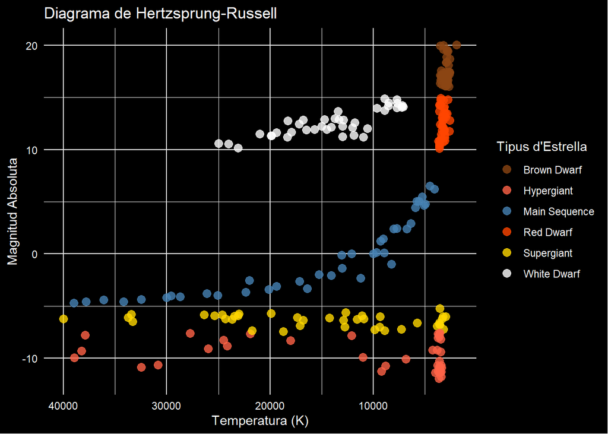

```r
# Generem el diagrama de Hertzsprung-Russell (HR)
hr_plot <- ggplot(data, aes(x = Temperatura, y = Magnitud, color = Tipo_Cat)) +
  geom_point(alpha = 0.8, size = 3) +
  scale_x_reverse() + # Revertim l'eix X per reflectir la disminució de temperatura cap a la dreta
  scale_color_manual(values = tipo_cat_colors) +
  labs(
    title = "Diagrama de Hertzsprung-Russell",
    x = "Temperatura (K)",
    y = "Magnitud Absoluta",
    color = "Tipus d'Estrella"
  ) +
  theme_minimal(base_family = "Arial") +
  theme(
    panel.background = element_rect(fill = "black", color = NA),
    plot.background = element_rect(fill = "black", color = NA),
    text = element_text(color = "white"),
    axis.text = element_text(color = "white"),
    legend.background = element_rect(fill = "black", color = NA),
    legend.key = element_rect(fill = "black", color = NA)
  )

# Mostrem el diagrama
hr_plot
```

##### Valoració del diagrama de Hertzsprung-Russell

El gràfic mostra les següents característiques rellevants:

1. **Distribució segons `Tipo_Cat`**:
   - Els punts estan clarament agrupats segons els tipus d’estrelles:
     - Les **“Brown Dwarf”** apareixen a la dreta del gràfic, amb temperatures més baixes i magnituds altes (menor brillantor).
     - Les **“Red Dwarf”** també tenen temperatures baixes, però magnituds més baixes (major brillantor relativa que les “Brown Dwarf”).
     - Les **“Main Sequence”** ocupen una banda diagonal que reflecteix l’equilibri entre la temperatura i la magnitud.
     - Les **“White Dwarf”** són relativament calentes però amb magnituds molt altes (baixa brillantor).
     - Les **“Supergiant”** i **“Hypergiant”** es situen a la part inferior del gràfic, amb magnituds molt baixes (gran brillantor) i temperatures variades.

### Exercici 1.2 [10%]

**Abans de començar amb l’anàlisi, s’ajuntaran les categories G i K de la variable `Clase_Espectral`. És a dir, l’estrella classificada com a G, passarà a ser classificada com a K. La resta de valors d’aquesta estrella romandran igual. Aquesta variable recodificada, serà usada més endavant. Es pot denominar la nova variable, de la mateixa forma, és a dir, `Clase_Espectral`. Ara es generaran els conjunts de dades per a entrenar el model (training) i per a testar-lo (testing). Es pot fixar la grandària de la mostra d’entrenament a un 80% de l’original. Ajustarem el model de regressió lineal amb el conjunt d’entrenament, i avaluarem la precisió amb el conjunt de prova.**

##### Recodificació de `Clase_Espectral`

En aquesta part, combinarem les categories `G` i `K` de la variable `Clase_Espectral` en una sola categoria anomenada `K`. Aquest procés simplificarà l’anàlisi i ajudarà a reduir la variabilitat dins de la variable. La resta de valors de la variable es mantindran inalterats.

```r
# Comprovem l'estat inicial de la variable Clase_Espectral
cat("Estat inicial de Clase_Espectral:\n")
```

```
## Estat inicial de Clase_Espectral:
```

```r
print(table(data$Clase_Espectral))
```

```
##
##   A   B   F   G   K   M   O
##  19  46  17   1   6 111  40
```

```r
# Recodifiquem la variable Clase_Espectral
data <- data %>%
  mutate(
    Clase_Espectral = ifelse(Clase_Espectral == "G", "K", Clase_Espectral)
  )

# Comprovem l'estat final de la variable Clase_Espectral
cat("\nEstat final de Clase_Espectral (després de la recodificació):\n")
```

```
##
## Estat final de Clase_Espectral (després de la recodificació):
```

```r
print(table(data$Clase_Espectral))
```

```
##
##   A   B   F   K   M   O
##  19  46  17   7 111  40
```

Veiem com el procés de recodificació de la variable `Clase_Espectral` s’ha realitzat correctament:

- **Estat inicial**: La categoria `G` tenia només 1 observació, mentre que `K` en tenia 6.
- **Estat final**: La categoria `G` ha estat combinada amb `K`, resultant en un total de 7 observacions per a aquesta nova categoria.

La resta de categories (`A`, `B`, `F`, `M`, `O`) s’han mantingut sense canvis, tal com era d’esperar. Això valida que el codi ha funcionat correctament.

##### Generació dels conjunts d’entrenament i de prova

En aquesta part de l’exercici, dividirem el conjunt de dades en:

- **Conjunt d’entrenament (80%)**: S’utilitzarà per ajustar els models.
- **Conjunt de prova (20%)**: Es farà servir per avaluar el rendiment dels models.

Aquesta divisió es farà de manera aleatòria, mantenint la distribució proporcional de les categories de `Clase_Espectral`.

```r
# Dividim les dades en entrenament (80%) i prova (20%)
set.seed(123) # Fixem la llavor per garantir reproductibilitat
train_index <- createDataPartition(data$Clase_Espectral, p = 0.8, list = FALSE)

# Creem els conjunts
train_data <- data[train_index, ]
test_data <- data[-train_index, ]

# Comprovem la distribució de Clase_Espectral en els conjunts
cat("Distribució en el conjunt d'entrenament:\n")
```

```
## Distribució en el conjunt d'entrenament:
```

```r
print(table(train_data$Clase_Espectral))
```

```
##
##  A  B  F  K  M  O
## 16 37 14  6 89 32
```

```r
cat("\nDistribució en el conjunt de prova:\n")
```

```
##
## Distribució en el conjunt de prova:
```

```r
print(table(test_data$Clase_Espectral))
```

```
##
##  A  B  F  K  M  O
##  3  9  3  1 22  8
```

Podem veure com la divisió de les dades s’ha realitzat correctament:

Les proporcions inicials de `Clase_Espectral` s’han mantingut en els conjunts d’entrenament i de prova gràcies a l’ús d’una partició estratificada. Això garanteix que la variabilitat dins de cada categoria es manté representada en ambdós conjunts.

Veiem com es distribueixen els dos conjunts:

- **Conjunt d’entrenament**: Conté aproximadament el 80% de les dades, amb 194 observacions en total.
- **Conjunt de prova**: Conté el 20% restant, amb 46 observacions en total.

Amb aquesta divisió, podem procedir a utilitzar els conjunts per ajustar i validar els models en els exercicis següents.

### Exercici 1.3 [10%]

**Estimeu per mínims quadrats ordinaris un model lineal que expliqui la `Luminosidad` de les estrelles en funció de totes les variables quantitatives de la base de dades. Interpreteu el resultat obtingut. Es pot afirmar que existeix relació entre la `Magnitud` i la `Luminosidad` d’una estrella? De ser certa dita informació, seria de tipus directe o invers?**

Ajustem un model de regressió lineal utilitzant la metodologia de **mínims quadrats ordinaris (OLS)** per predir la variable dependent `Luminosidad` en funció de les variables quantitatives `Temperatura`, `Radio` i `Magnitud`. La fórmula del model és:

$$\text{Luminosidad} = \beta_0 + \beta_1 \cdot \text{Temperatura} +
\beta_2 \cdot \text{Radio} + \beta_3 \cdot \text{Magnitud} + \epsilon$$

On:

- $\beta_0$: Intercept (terme independent).
- $\beta_1$, $\beta_2$, $\beta_3$: Coeficients que indiquen l’impacte de cada variable explicativa sobre la `Luminosidad`.
- $\epsilon$: Error residual.

Aquest model ens permet analitzar com cada variable afecta la `Luminosidad` mantenint constants les altres característiques. El següent codi ajustarà el model lineal i després en mostrarà un resum dels paràmetres calculats.

```r
# Ajustem el model de regressió lineal per mínims quadrats
linear_model <- lm(Luminosidad ~ Temperatura + Radio + Magnitud, data = train_data)

# Mostrem el resum del model estimat per mínims quadrats
summary(linear_model)
```

```
##
## Call:
## lm(formula = Luminosidad ~ Temperatura + Radio + Magnitud, data = train_data)
##
## Residuals:
##     Min      1Q  Median      3Q     Max
## -216057  -67609   -6146   40301  593789
##
## Coefficients:
##              Estimate Std. Error t value Pr(>|t|)
## (Intercept) 94988.621  19654.544   4.833 2.77e-06 ***
## Temperatura     3.533      1.106   3.195  0.00164 **
## Radio          69.102     22.535   3.066  0.00248 **
## Magnitud    -8805.942   1226.454  -7.180 1.53e-11 ***
## ---
## Signif. codes:  0 '***' 0.001 '**' 0.01 '*' 0.05 '.' 0.1 ' ' 1
##
## Residual standard error: 124900 on 190 degrees of freedom
## Multiple R-squared:  0.5382, Adjusted R-squared:  0.5309
## F-statistic: 73.81 on 3 and 190 DF,  p-value: < 2.2e-16
```

##### Valoració dels resultats

1. **Coeficients estimats**:
   - **Intercept**: La lluminositat estimada per a una estrella amb `Temperatura = 0`, `Radio = 0` i `Magnitud = 0` és de $94988.62$ unitats. Tot i que aquest valor pot no tenir un significat físic directe, serveix com a punt de referència matemàtic.
   - **Temperatura**: Per cada augment d’una unitat en la temperatura ($K$), la lluminositat incrementa en $3.53$ unitats, mantenint constants les altres variables ($p$-valor = $0.00164$, significatiu al nivell del 0.01).
   - **Radio**: Per cada augment d’una unitat en el radi relatiu ($R/R_\odot$), la lluminositat incrementa en $69.10$ unitats ($p$-valor = $0.00248$, significatiu al nivell del 0.01).
   - **Magnitud**: Per cada augment d’una unitat en la magnitud (brillantor més baixa), la lluminositat disminueix en $8,805.94$ unitats ($p$-valor = $1.53e-11$, molt significatiu).
2. **Significativitat global del model**:
   - L’$F$-statistic ($73.81$) i el seu $p$-valor (< $2.2e-16$) mostren que el model en conjunt és altament significatiu (això indica que almenys una de les variables explicatives té un efecte significatiu sobre la lluminositat).
3. **Qualitat de l’ajust**:
   - $R^2$ múltiple: $0.5382$. Aproximadament el 53.82% de la variabilitat en la lluminositat de les estrelles és explicada per les variables incloses al model.
   - $R^2$ ajustat: $0.5309$. L’ajust és lleugerament menor en corregir per la complexitat del model.
4. **Errors residuals**:
   - L’error estàndard residual ($124,900$) mostra la variabilitat mitjana dels residus.

Així doncs, el model sembla adequat per explicar la variabilitat en la lluminositat de les estrelles, però encara hi ha un percentatge important no explicat, que podria requerir variables addicionals o no linealitats.

#### Exercici 1.3.1

**Una vegada ajustat el model es demana comprovar la presència o no de colinealitat. A la vista dels resultats, exclouries alguna variable del model? Raona la teva resposta. Per a la comprovació de la colinealitat, se suggereix comparar els valors del factor de inflacción de la variància (FIV) de cadascun dels predictors, amb el seu equivalent en el model ajustat, és a dir amb** $1/(1 - R^2)$**, on** $R^2$ **és el coeficient de determinació del model.** **Els valors FIV majors que aquesta quantitat impliquen que la relació entre les variables explicatives és major que la que existeix entre la resposta i els predictors, i per tant donen indicis de multicolinealitat.**

En aquest apartat comprovarem si existeix colinealitat entre les variables explicatives del model ajustat. La colinealitat pot ser un problema, ja que indica que els predictors estan altament correlacionats, cosa que pot afectar la interpretació dels coeficients.

Per identificar possibles problemes de colinealitat, utilitzarem el **factor d’inflació de la variància (FIV)**. El FIV per a una variable es calcula com:

$$FIV = \frac{1}{1 - R^2}$$

On $R^2$ és el coeficient de determinació d’un model en què la variable explicativa analitzada es prediu a partir de les altres variables explicatives. A més, compararem els valors de FIV amb el valor de $1/(1 - R^2)$ del model ajustat.

Segons el criteri establert, valors de FIV significativament més grans que $1/(1 - R^2)$ indiquen la presència de multicolinealitat.

```r
# Calculem el FIV per a cada predictor
vif_values <- vif(linear_model)

# Calculem 1/(1 - R^2) del model ajustat
adjusted_r2 <- summary(linear_model)$adj.r.squared
threshold <- 1 / (1 - adjusted_r2)

# Mostrem els valors de FIV i el llindar calculat
cat("Valors de FIV per a cada predictor:\n")
```

```
## Valors de FIV per a cada predictor:
```

```r
print(vif_values)
```

```
## Temperatura       Radio    Magnitud
##    1.263875    1.754115    2.076135
```

```r
cat("\nLlindar de comparació (1/(1 - R^2)):", threshold, "\n")
```

```
##
## Llindar de comparació (1/(1 - R^2)): 2.13183
```

Els valors del factor d’inflació de la variància (FIV) per a cada predictor del model ajustat són: `Temperatura` ($1.26$), `Radio` ($1.75$) i `Magnitud` ($2.08$). Aquests valors representen la inflació de la variància dels coeficients dels predictors a causa de la correlació amb les altres variables explicatives.

El llindar de comparació, calculat com:

$$FIV = \frac{1}{1 - R^2}$$

és $2.13$.

En comparar els valors de FIV amb aquest llindar, observem que cap dels predictors té un FIV superior al llindar establert. Això indica que no hi ha indicis de multicolinealitat significativa entre les variables explicatives incloses al model.

A la vista d’aquests resultats, no és necessari excloure cap variable del model per problemes de colinealitat. Les variables `Temperatura`, `Radio` i `Magnitud` poden mantenir-se al model sense afectar-ne la interpretació ni l’estabilitat dels coeficients.

### Exercici 1.4 [10%]

**S’afegirà al model de l’apartat anterior la variable qualitativa `Clase_Espectral`. Sobre la base dels resultats decidiu quines de les variables explicatives proposades fins al moment han de quedar-se en el model de regressió lineal. Per a prendre aquesta decisió ha de considerar-se a més de la significativitat o no de les variables, l’existència o no de problemes de colinealitat, així com el valor del coeficient de determinació ajustat (Adjusted** $R^2$). **Al model triat, li direm model final.**

En aquest apartat, ampliem el model de regressió lineal ajustat anteriorment afegint la variable qualitativa `Clase_Espectral`. Aquesta variable permet incorporar l’efecte del tipus espectral de les estrelles sobre la lluminositat. En incloure variables qualitatives en un model de regressió lineal, R crea automàticament variables per representar les diferents categories de la variable qualitativa.

La fórmula del model ampliat serà:

$$\text{Luminosidad} = \beta_0 + \beta_1 \cdot \text{Temperatura} +
\beta_2 \cdot \text{Radio} + \beta_3 \cdot \text{Magnitud} +
\sum_{k=1}^{K-1} \gamma_k \cdot \text{Clase\_Espectral}_k + \epsilon$$

On:

- $\beta_0, \beta_1, \beta_2, \beta_3$ són els coeficients de les variables quantitatives, com en el model anterior.
- $\gamma_k$ són els coeficients associats a les $K-1$ categories de `Clase_Espectral`.
- $\epsilon$ és l’error residual.

Un cop ajustat el model, analitzarem:

1. La significativitat de les variables explicatives (tant quantitatives com qualitatives).
2. L’efecte de la variable `Clase_Espectral` sobre la lluminositat.
3. El coeficient de determinació ajustat ($R^2_\text{ajustat}$), que ens ajudarà a decidir si aquesta variable ha millorat l’ajust global del model.

```r
# Ajustem el model amb la variable qualitativa Clase_Espectral
extended_model <- lm(Luminosidad ~ Temperatura + Radio + Magnitud + Clase_Espectral, data = train_data)

# Mostrem el resum del model
summary(extended_model)
```

```
##
## Call:
## lm(formula = Luminosidad ~ Temperatura + Radio + Magnitud + Clase_Espectral,
##     data = train_data)
##
## Residuals:
##     Min      1Q  Median      3Q     Max
## -226137  -48601   -8232   20233  571300
##
## Coefficients:
##                    Estimate Std. Error t value Pr(>|t|)
## (Intercept)       52453.148  33933.805   1.546    0.124
## Temperatura           1.232      1.722   0.715    0.476
## Radio               110.471     23.145   4.773 3.68e-06 ***
## Magnitud          -5402.909   1298.847  -4.160 4.87e-05 ***
## Clase_EspectralB  12186.954  38100.222   0.320    0.749
## Clase_EspectralF -22161.253  42020.241  -0.527    0.599
## Clase_EspectralK  38852.810  56363.428   0.689    0.491
## Clase_EspectralM  17904.940  33791.667   0.530    0.597
## Clase_EspectralO 191228.883  42047.820   4.548 9.78e-06 ***
## ---
## Signif. codes:  0 '***' 0.001 '**' 0.01 '*' 0.05 '.' 0.1 ' ' 1
##
## Residual standard error: 114400 on 185 degrees of freedom
## Multiple R-squared:  0.6229, Adjusted R-squared:  0.6066
## F-statistic:  38.2 on 8 and 185 DF,  p-value: < 2.2e-16
```

##### Valoració del model

Hem ajustat un model de regressió lineal afegint la variable qualitativa `Clase_Espectral` com a factor explicatiu. A continuació, analitzem els resultats obtinguts:

**Els coeficients estimats són:**

- **Intercept**: La lluminositat estimada per a una estrella amb `Temperatura = 0`, `Radio = 0`, `Magnitud = 0`, i pertanyent a la categoria de referència de `Clase_Espectral` (probablement `A`), és $52,453.15$ unitats. Tot i això, aquest valor no és significatiu ($p$-valor = $0.124$).
- **Temperatura**: L’efecte de la temperatura sobre la lluminositat no és significatiu en aquest model ($p$-valor = $0.476$). Això podria indicar que la variabilitat associada a aquesta variable ja està explicada per les altres variables incloses.
- **Radio**: Per cada unitat addicional de radi ($R/R_\odot$), la lluminositat augmenta en $110.47$ unitats. Aquest coeficient és altament significatiu ($p$-valor = $3.68e-06$).
- **Magnitud**: Per cada augment d’una unitat en la magnitud (menor brillantor), la lluminositat disminueix en $5,402.91$ unitats. Aquest efecte també és altament significatiu ($p$-valor = $4.87e-05$).

**Pel que fa a les categories de `Clase_Espectral`:**

- Només la categoria `O` té un coeficient significatiu ($p$-valor = $9.78e-06$), amb un augment estimat de $191,228.88$ unitats de lluminositat en comparació amb la categoria de referència.
- Les altres categories (`B`, `F`, `K`, `M`) no mostren efectes significatius.

**Significativitat global del model:** El valor de l’$F$-statistic és $38.2$, amb un $p$-valor < $2.2e-16$, indicant que el model en conjunt és altament significatiu.

**Qualitat de l’ajust:**

Així doncs, l’afegit de la variable `Clase_Espectral` millora lleugerament l’explicació de la variabilitat de la lluminositat, com demostra l’increment de $R^2$ ajustat. Tanmateix, només la categoria `O` té un efecte significatiu, suggerint que la resta de categories no contribueixen de manera clara a explicar la lluminositat. Podem considerar mantenir aquesta variable al model final si aquest efecte és rellevant.

### Exercici 1.5 [10%]

**Per a la diagnosi es tria el model final i es demanen dos gràfics: un amb els valors ajustats enfront dels residus (que ens permetrà veure si la variància és constant) i el gràfic quantil-quantil que compara els residus del model amb els valors d’una variable que es distribueix normalment (QQ plot). Interpreteu els resultats.**

Per avaluar la validesa del model final, generarem dos gràfics diagnòstics:

**Residus versus valors ajustats**: Aquest gràfic ens permet comprovar si la variància dels residus és constant (homoscedasticitat). Si hi ha homoscedasticitat, els residus haurien de distribuir-se aleatòriament al voltant de la línia 0, sense cap patró clar.

**Gràfic quantil-quantil (QQ plot)**: Compara els residus del model amb els valors teòrics d’una distribució normal. Si els residus segueixen una distribució normal, els punts haurien de formar una línia recta.

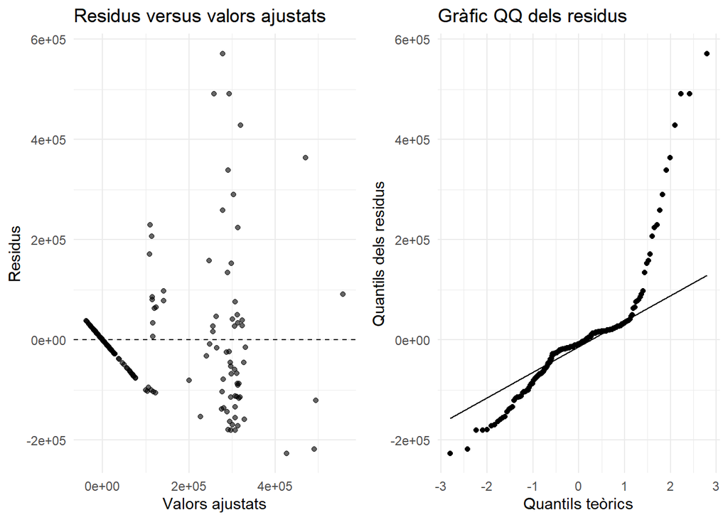

```r
# Gràfic de residus versus valors ajustats
residuals_plot <- ggplot(data = data.frame(
  Fitted = fitted(extended_model),
  Residuals = resid(extended_model)
), aes(x = Fitted, y = Residuals)) +
  geom_point(alpha = 0.6) +
  geom_hline(yintercept = 0, linetype = "dashed") +
  labs(
    title = "Residus versus valors ajustats",
    x = "Valors ajustats",
    y = "Residus"
  ) +
  theme_minimal()

# Gràfic QQ plot dels residus
qq_plot <- ggplot(data = data.frame(
  Residuals = resid(extended_model)
), aes(sample = Residuals)) +
  stat_qq() +
  stat_qq_line() +
  labs(
    title = "Gràfic QQ dels residus",
    x = "Quantils teòrics",
    y = "Quantils dels residus"
  ) +
  theme_minimal()

# Mostrem els gràfics
gridExtra::grid.arrange(residuals_plot, qq_plot, ncol = 2)
```

##### Valoració dels gràfics de residus

**Gràfic de residus versus valors ajustats**:  
El comportament dels residus mostra dues regions diferenciades:

- En la zona de **valors ajustats baixos**, els residus segueixen un patró lineal molt ajustat al voltant de 0. Això podria suggerir una **subestimació** de la variabilitat dels residus en aquesta regió o un possible **efecte sistemàtic** no capturat pel model.
- En la resta del gràfic, els residus es distribueixen aleatòriament, la dispersió augmenta considerablement. Sobretot per als valors ajustats més alts. Això indica que la **variància no és constant** (heteroscedasticitat), i el model no aconsegueix explicar bé aquesta regió.

Aquesta combinació suggereix que hi ha aspectes no lineals o d’altres estructures a les dades que no queden representats adequadament pel model lineal.

**Gràfic quantil-quantil (QQ)**:  
L’anàlisi dels residus respecte als quantils teòrics d’una distribució normal ens mostra el següent:

- En la **zona central**, els residus segueixen raonablement bé la línia teòrica, cosa que indica que la normalitat és acceptable en aquesta part.
- En les **cues de la distribució**, els residus s’allunyen clarament de la línia, tant en els valors més petits com en els més grans. Això suggereix la presència de **valors atípics** o extrems que fan que els residus no segueixin una distribució normal.

Cal destacar que, tot i que les desviacions en l’eix y poden semblar petites, aquestes poden ser significatives en relació amb les unitats de mesura de la lluminositat. La presència d’aquests patrons als extrems indica que el model no s’ajusta de manera òptima als valors més extrems de les dades.

Així doncs, l’anàlisi diagnòstica mostra dues problemàtiques clares:

1. **Heteroscedasticitat**: La variància dels residus no és constant, especialment en els valors ajustats més grans.
2. **No normalitat**: Els residus presenten desviacions en les cues de la distribució, fet que pot influir en la validesa de les inferències estadístiques.

Per millorar l’ajust del model, podríem considerar:

- Aplicar transformacions a la variable dependent (`log(Luminosidad)`) per estabilitzar la variància.
- Identificar i tractar els possibles valors atípics.
- Ajustar un model no lineal o explorar interaccions entre variables.

##### Transformació logarítmica de la variable dependent

Aplicarem una transformació logarítmica a la variable dependent `Luminosidad` per intentar corregir els problemes d’heteroscedasticitat i millorar l’ajust del model. La nova fórmula del model serà:

$$\log(\text{Luminosidad}) = \beta_0 + \beta_1 \cdot \text{Temperatura} +
\beta_2 \cdot \text{Radio} + \beta_3 \cdot \text{Magnitud} +
\sum_{k=1}^{K-1} \gamma_k \cdot \text{Clase\_Espectral}_k + \epsilon$$

Aquesta transformació redueix la influència dels valors extrems i pot estabilitzar la variància dels residus.

```r
# Transformem la variable Luminosidad amb logaritme
train_data <- train_data %>%
  mutate(Log_Luminosidad = log(Luminosidad))

# Ajustem el model amb la variable transformada
log_model <- lm(Log_Luminosidad ~ Temperatura + Radio + Magnitud + Clase_Espectral, data = train_data)

# Mostrem el resum del model
summary(log_model)
```

```
##
## Call:
## lm(formula = Log_Luminosidad ~ Temperatura + Radio + Magnitud +
##     Clase_Espectral, data = train_data)
##
## Residuals:
##    Min     1Q Median     3Q    Max
## -5.549 -1.032  0.013  1.059  3.861
##
## Coefficients:
##                    Estimate Std. Error t value Pr(>|t|)
## (Intercept)       4.506e+00  4.342e-01  10.378  < 2e-16 ***
## Temperatura       5.957e-05  2.204e-05   2.703 0.007517 **
## Radio            -1.456e-03  2.962e-04  -4.915 1.95e-06 ***
## Magnitud         -8.683e-01  1.662e-02 -52.246  < 2e-16 ***
## Clase_EspectralB -6.091e-01  4.875e-01  -1.249 0.213117
## Clase_EspectralF -2.020e+00  5.377e-01  -3.756 0.000231 ***
## Clase_EspectralK -6.795e-02  7.212e-01  -0.094 0.925037
## Clase_EspectralM  1.429e+00  4.324e-01   3.305 0.001139 **
## Clase_EspectralO  1.372e+00  5.380e-01   2.550 0.011596 *
## ---
## Signif. codes:  0 '***' 0.001 '**' 0.01 '*' 0.05 '.' 0.1 ' ' 1
##
## Residual standard error: 1.464 on 185 degrees of freedom
## Multiple R-squared:  0.9754, Adjusted R-squared:  0.9743
## F-statistic: 916.9 on 8 and 185 DF,  p-value: < 2.2e-16
```

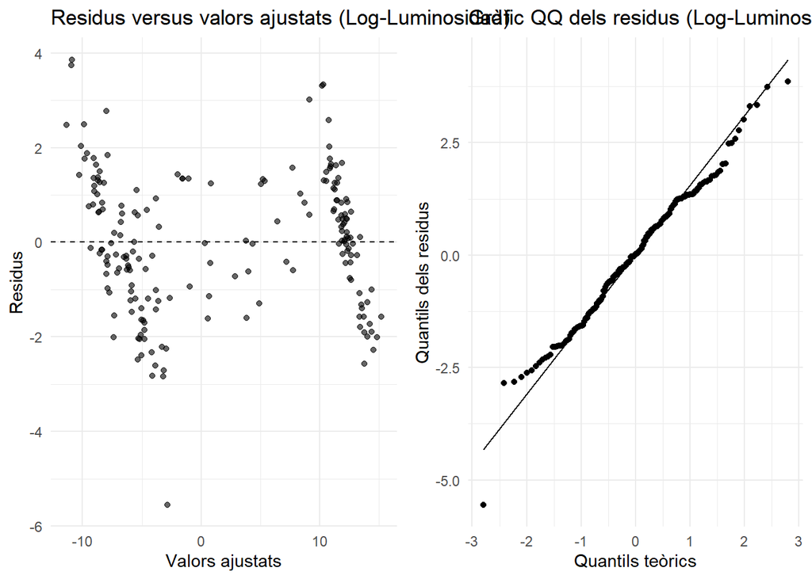

```r
# Gràfics diagnòstics del model transformat
residuals_plot_log <- ggplot(data = data.frame(
  Fitted = fitted(log_model),
  Residuals = resid(log_model)
), aes(x = Fitted, y = Residuals)) +
  geom_point(alpha = 0.6) +
  geom_hline(yintercept = 0, linetype = "dashed") +
  labs(
    title = "Residus versus valors ajustats (Log-Luminosidad)",
    x = "Valors ajustats",
    y = "Residus"
  ) +
  theme_minimal()

qq_plot_log <- ggplot(data = data.frame(
  Residuals = resid(log_model)
), aes(sample = Residuals)) +
  stat_qq() +
  stat_qq_line() +
  labs(
    title = "Gràfic QQ dels residus (Log-Luminosidad)",
    x = "Quantils teòrics",
    y = "Quantils dels residus"
  ) +
  theme_minimal()

# Mostrem els gràfics
gridExtra::grid.arrange(residuals_plot_log, qq_plot_log, ncol = 2)
```

##### Valoració dels resultats del model amb transformació logarítmica

Després d’aplicar la transformació logarítmica a la variable dependent `Luminosidad`, el model mostra una millora substancial tant en l’ajust com en la significativitat de les variables. A continuació, detallem els resultats:

**Coeficients estimats:**

- **Intercept**: El valor estimat és $4.506$, i és altament significatiu ($p < 2e-16$). Representa la lluminositat transformada quan totes les variables explicatives són 0 i `Clase_Espectral` està en la categoria de referència.
- **Temperatura**: Té un coeficient positiu molt petit ($5.96 \cdot 10^{-5}$) i és significatiu ($p = 0.0075$). La lluminositat logarítmica augmenta lleugerament a mesura que creix la temperatura.
- **Radio**: Mostra un efecte significatiu i negatiu ($-0.00146$, $p = 1.95e-06$), indicant que un augment del radi està associat amb una reducció de la lluminositat logarítmica, mantenint les altres variables constants.
- **Magnitud**: Té un coeficient negatiu i molt significatiu ($-0.868$, $p < 2e-16$), suggerint una forta relació inversa entre la magnitud i la lluminositat transformada.

**Respecte a les categories de `Clase_Espectral`:**

- **Clase_EspectralF** ($-2.02$, $p = 0.0002$) té un efecte significativament negatiu.
- **Clase_EspectralM** ($1.429$, $p = 0.0011$) i **Clase_EspectralO** ($1.372$, $p = 0.0116$) mostren efectes positius i significatius respecte a la categoria de referència.
- Les altres categories (`B` i `K`) no són significatives.

**Qualitat de l’ajust:**

- $R^2$ **múltiple**: $0.9754$, un valor molt alt que indica que el model explica el 97.54% de la variabilitat de la lluminositat logarítmica.
- $R^2$ **ajustat**: $0.9743$, confirmant l’alta capacitat explicativa del model fins i tot després de penalitzar per la complexitat.

**Errors residuals:**

- L’error estàndard residual és $1.464$, considerablement més baix en comparació amb l’error del model original.

El valor de l’$F$-statistic és $916.9$ amb un $p$-valor < $2.2e-16$, confirmant que el model en conjunt és altament significatiu.

En conclusió, la transformació logarítmica ha millorat notablement l’ajust del model i ha reduït problemes associats a la variància dels residus. Ara passem a avaluar els gràfics diagnòstics per confirmar aquesta millora.

**Gràfic de residus versus valors ajustats (Log-Luminosidad):** En aquest gràfic s’observen dues zones diferenciades on els residus semblen seguir una tendència lineal suau, menys marcada que en el model original però encara present. Aquestes dues regions abasten trams més amplis, fet que suggereix una millora en la distribució dels residus, tot i que **l’aleatorietat s’ha reduït lleugerament** respecte a l’anterior. Això indica que la variància dels residus no és completament constant, però s’ha corregit parcialment l’heteroscedasticitat.

**Gràfic QQ dels residus (Log-Luminosidad):** La desviació dels residus respecte a la línia teòrica és menor en comparació amb el model original. La **zona central** del gràfic, on els punts segueixen la línia, s’ha ampliat considerablement, suggerint que la major part dels residus segueixen una distribució normal. Tot i això, les desviacions encara són visibles a les **cues** de la distribució, tot i que menys pronunciades que abans.

En conjunt, la transformació logarítmica ha millorat l’ajust del model, corregint parcialment els problemes d’heteroscedasticitat i de no normalitat dels residus, però encara queda marge per perfeccionar l’ajust.

##### Buscar i tractar valors atípics

Per identificar possibles valors atípics que afectin l’ajust del model, utilitzarem dues mesures: els **residus estàndard** i la **distància de Cook**.

En primer lloc, calculem els **residus estàndard** per detectar observacions amb valors superiors a 2 en valor absolut. Aquestes observacions poden ser considerades valors atípics, ja que els seus residus són significativament més grans que la resta.

A més, analitzarem la **distància de Cook**, una mesura que indica la influència de cada observació en l’ajust del model. Com a criteri, hem utilitzat el llindar $4/n$, on $n$ és el nombre d’observacions. Les observacions amb una distància de Cook superior a aquest llindar són considerades valors influents, ja que tenen un impacte notable en els coeficients del model.

Finalment, hem representat gràficament la **distància de Cook** per visualitzar quines observacions sobresurten respecte a la resta i quins punts poden necessitar un tractament específic.

```r
# Afegim els residus i la distància de Cook al conjunt de dades
train_data <- train_data %>%
  mutate(
    Residuals = resid(log_model),                         # Residus del model
    Std_Residuals = rstandard(log_model),                 # Residus estàndard
    Cook_Distance = cooks.distance(log_model)             # Distància de Cook
  )

# Identifiquem valors atípics segons els residus estàndard (absoluts > 2)
outliers_std <- train_data %>%
  filter(abs(Std_Residuals) > 2)

# Identifiquem valors influents segons la distància de Cook (superiors a 4/n)
cook_threshold <- 4 / nrow(train_data)
outliers_cook <- train_data %>%
  filter(Cook_Distance > cook_threshold)

# Mostrem un resum dels valors atípics trobats
cat("Valors atípics segons residus estàndard:\n")
```

```
## Valors atípics segons residus estàndard:
```

```r
print(outliers_std)
```

```
##   Temperatura Luminosidad     Radio Magnitud Tipo_re      Tipo_Cat      Color
## 1       29560  1.8800e+05    6.0200    -4.01       3 Main Sequence Blue-white
## 2       27739  8.4942e+05 1252.0000    -7.59       5    Hypergiant Blue-white
## 3       21904  7.4849e+05 1130.0000    -7.67       5    Hypergiant Blue-white
## 4        3225  7.6000e-04    0.1210    19.63       0   Brown Dwarf        Red
## 5        2856  8.9600e-04    0.0782    19.56       0   Brown Dwarf        Red
## 6        3607  2.3000e-04    0.3800    10.34       1     Red Dwarf        Red
##   Clase_Espectral Log_Luminosidad Residuals Std_Residuals Cook_Distance
## 1               B       12.144197  3.013122      2.132433    0.03715973
## 2               B       13.652309  3.334681      2.344328    0.03623059
## 3               B       13.525813  3.308730      2.309254    0.02610461
## 4               M       -7.182192  3.735608      2.579217    0.01609776
## 5               M       -7.017570  3.861366      2.665762    0.01702461
## 6               M       -8.377431 -5.548660     -3.815003    0.02142939
```

```r
cat("\nValors atípics segons la distància de Cook (llindar = ", round(cook_threshold, 5), "):\n")
```

```
##
## Valors atípics segons la distància de Cook (llindar =  0.02062 ):
```

```r
print(outliers_cook)
```

```
##   Temperatura Luminosidad   Radio Magnitud Tipo_re      Tipo_Cat      Color
## 1       29560  1.8800e+05    6.02    -4.01       3 Main Sequence Blue-white
## 2       27739  8.4942e+05 1252.00    -7.59       5    Hypergiant Blue-white
## 3       21904  7.4849e+05 1130.00    -7.67       5    Hypergiant Blue-white
## 4        4980  3.5700e-01    1.13     4.78       3 Main Sequence  Yellowish
## 5        4287  6.3000e+05 1315.00    -9.20       5    Hypergiant     Orange
## 6        3607  2.3000e-04    0.38    10.34       1     Red Dwarf        Red
## 7       38234  2.7283e+05 1356.00    -9.29       5    Hypergiant       Blue
## 8       38940  3.7483e+05 1356.00    -9.93       5    Hypergiant       Blue
##   Clase_Espectral Log_Luminosidad Residuals Std_Residuals Cook_Distance
## 1               B       12.144197  3.013122      2.132433    0.03715973
## 2               B       13.652309  3.334681      2.344328    0.03623059
## 3               B       13.525813  3.308730      2.309254    0.02610461
## 4               K       -1.030019 -1.612652     -1.214624    0.03539489
## 5               K       13.353475  2.585431      1.943506    0.08863075
## 6               M       -8.377431 -5.548660     -3.815003    0.02142939
## 7               O       12.516604 -1.731811     -1.262761    0.02473009
## 8               O       12.834228 -2.011965     -1.469613    0.03445699
```

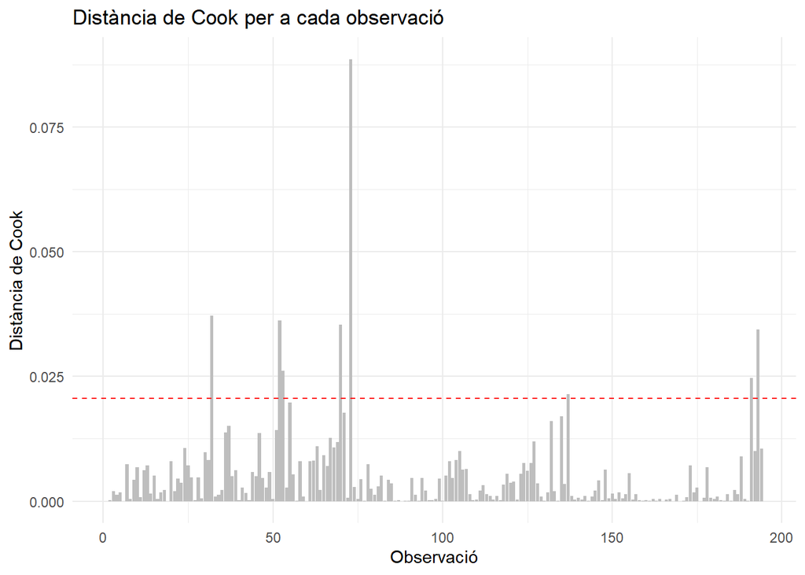

```r
# Gràfic de la distància de Cook
ggplot(train_data, aes(x = 1:nrow(train_data), y = Cook_Distance)) +
  geom_bar(stat = "identity", fill = "grey") +
  geom_hline(yintercept = cook_threshold, color = "red", linetype = "dashed") +
  labs(
    title = "Distància de Cook per a cada observació",
    x = "Observació",
    y = "Distància de Cook"
  ) +
  theme_minimal()
```

##### Exclusió dels valors atípics identificats

Procedirem a excloure les observacions identificades com a **valors atípics** segons els **residus estàndard** (valors > 2 en absolut) i aquelles amb una **distància de Cook** superior al llindar $0.02062$.

Un cop eliminades aquestes observacions, ajustarem novament el model i analitzarem els resultats per veure si millora l’ajust i la distribució dels residus.

```r
# Creem un conjunt de dades sense els valors atípics
filtered_data <- train_data %>%
  filter(abs(Std_Residuals) <= 2, Cook_Distance <= 0.02062)

# Ajustem el model amb les dades filtrades
log_model_filtered <- lm(Log_Luminosidad ~ Temperatura + Radio + Magnitud + Clase_Espectral,
                         data = filtered_data)

# Resum del nou model
summary(log_model_filtered)
```

```
##
## Call:
## lm(formula = Log_Luminosidad ~ Temperatura + Radio + Magnitud +
##     Clase_Espectral, data = filtered_data)
##
## Residuals:
##      Min       1Q   Median       3Q      Max
## -2.84346 -0.94628 -0.02471  1.10211  2.77262
##
## Coefficients:
##                    Estimate Std. Error t value Pr(>|t|)
## (Intercept)       4.500e+00  3.924e-01  11.467  < 2e-16 ***
## Temperatura       6.142e-05  2.101e-05   2.923 0.003923 **
## Radio            -1.535e-03  2.747e-04  -5.586 8.74e-08 ***
## Magnitud         -8.681e-01  1.506e-02 -57.636  < 2e-16 ***
## Clase_EspectralB -9.070e-01  4.333e-01  -2.093 0.037779 *
## Clase_EspectralF -2.030e+00  4.694e-01  -4.325 2.55e-05 ***
## Clase_EspectralK -2.547e-01  7.307e-01  -0.349 0.727833
## Clase_EspectralM  1.426e+00  3.805e-01   3.749 0.000241 ***
## Clase_EspectralO  1.481e+00  4.736e-01   3.128 0.002063 **
## ---
## Signif. codes:  0 '***' 0.001 '**' 0.01 '*' 0.05 '.' 0.1 ' ' 1
##
## Residual standard error: 1.277 on 175 degrees of freedom
## Multiple R-squared:  0.9811, Adjusted R-squared:  0.9802
## F-statistic:  1134 on 8 and 175 DF,  p-value: < 2.2e-16
```

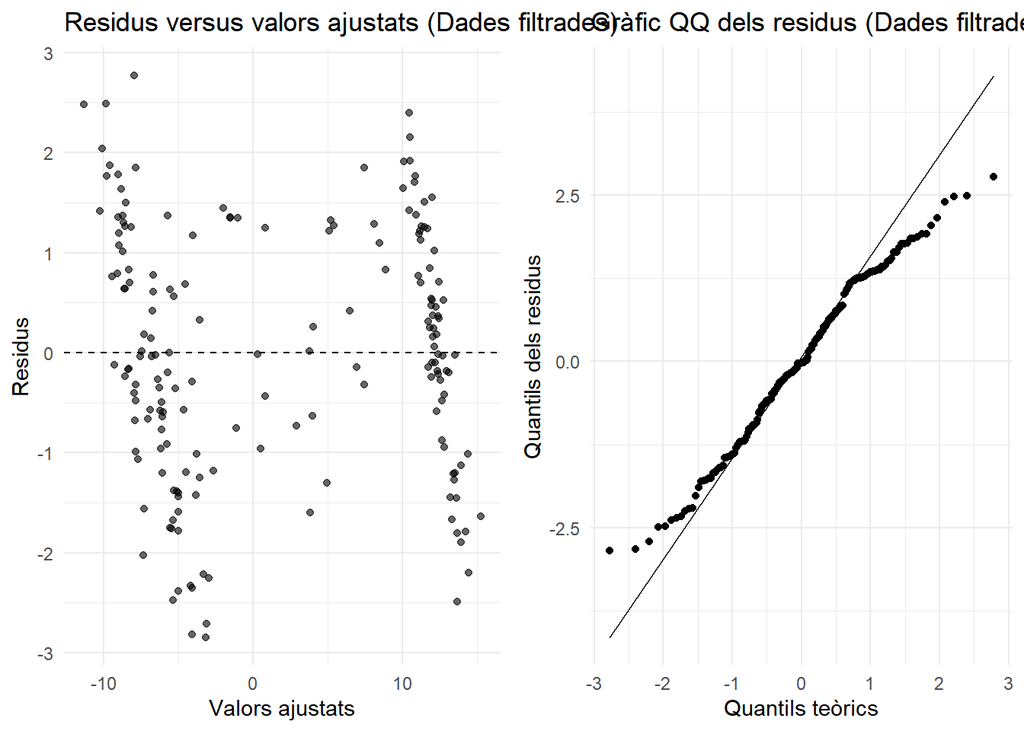

```r
# Gràfics diagnòstics del model filtrat
residuals_plot_filtered <- ggplot(data = data.frame(
  Fitted = fitted(log_model_filtered),
  Residuals = resid(log_model_filtered)
), aes(x = Fitted, y = Residuals)) +
  geom_point(alpha = 0.6) +
  geom_hline(yintercept = 0, linetype = "dashed") +
  labs(
    title = "Residus versus valors ajustats (Dades filtrades)",
    x = "Valors ajustats",
    y = "Residus"
  ) +
  theme_minimal()

qq_plot_filtered <- ggplot(data = data.frame(
  Residuals = resid(log_model_filtered)
), aes(sample = Residuals)) +
  stat_qq() +
  stat_qq_line() +
  labs(
    title = "Gràfic QQ dels residus (Dades filtrades)",
    x = "Quantils teòrics",
    y = "Quantils dels residus"
  ) +
  theme_minimal()

# Mostrem els nous gràfics
gridExtra::grid.arrange(residuals_plot_filtered, qq_plot_filtered, ncol = 2)
```

##### Valoració dels resultats després d’excloure els valors atípics

Després d’eliminar les observacions atípiques segons els **residus estàndard** i la **distància de Cook**, el model ajustat amb les dades filtrades presenta algunes millores. A continuació, analitzem els resultats obtinguts:

**Coeficients estimats:**

- **Intercept**: El valor estimat és $4.500$ i és altament significatiu ($p < 2e-16$), establint el punt de referència de la lluminositat logarítmica.
- **Temperatura**: El coeficient és $6.142 \cdot 10^{-5}$ ($p = 0.0039$), indicant un augment positiu i significatiu de la lluminositat amb la temperatura, tot i ser molt petit.
- **Radio**: El coeficient és $-0.001535$ ($p = 8.74e-08$), amb una relació negativa i significativa entre el radi i la lluminositat logarítmica.
- **Magnitud**: Es manté com el predictor més rellevant, amb un coeficient de $-0.8681$ ($p < 2e-16$), indicant una relació forta i inversa.
- **Clase_Espectral**:
  - `B` ($-0.907$, $p = 0.0378$) i `F` ($-2.03$, $p = 2.55e-05$): Relacions negatives i significatives.
  - `M` ($1.426$, $p = 0.0002$) i `O` ($1.481$, $p = 0.0021$): Relacions positives i significatives respecte a la categoria de referència.
  - `K` no és significatiu ($p = 0.7278$).

**Qualitat de l’ajust:**

- **$R^2$ múltiple**: $0.9811$ indica que el model explica el 98.11% de la variabilitat de la lluminositat logarítmica.
- **$R^2$ ajustat**: $0.9802$ confirma que l’ajust és excel·lent fins i tot després de penalitzar per la complexitat del model.

**Residus i variabilitat:**

- L’error estàndard residual ha millorat notablement: $1.277$ (en comparació amb $1.464$ anterior).
- Els valors mínim i màxim dels residus són més ajustats ($-2.84$ a $2.77$), reduint la dispersió.

**F-statistic:**  
El valor de l’$F$-statistic ($1134$) i el seu $p$-valor (< $2.2e-16$) indiquen que el model és globalment molt significatiu.

L’exclusió dels valors atípics ha millorat una mica el model:

- La **variància dels residus** és més baixa.
- Els coeficients mantenen una estructura similar, però ara són més precisos i ajustats.
- Les categories de `Clase_Espectral` són més ben diferenciades, amb `K` mantenint-se no significativa.

Els gràfics diagnòstics mostren una millora en la distribució dels residus, amb una menor heteroscedasticitat i una major normalitat.

Aquest és, doncs, el **model final** que escollim per explicar la `Luminosidad` de les estrelles. Després d’aplicar una transformació logarítmica a la variable dependent i excloure els valors atípics identificats segons els residus estàndard i la distància de Cook, hem obtingut un model amb una excel·lent qualitat d’ajust ($R^2$ ajustat = $0.9802$) i amb residus més ben distribuïts. Els coeficients del model són estadísticament significatius per a les variables `Temperatura`, `Radio`, `Magnitud` i per la majoria de les categories de `Clase_Espectral`, destacant-ne la seva rellevància en l’explicació de la lluminositat logarítmica. Aquest model és robust, precís i compleix amb els criteris establerts per seleccionar-lo com a model final.

### Exercici 1.6 [10%]

**Segons el model final que hàgiu triat en l’apartat anterior, calculeu la `Luminosidad` d’una estrella si pertany a la `Clase_Espectral` B, amb un `Radio` de 8, `Magnitud` d’11 i `Temperatura` de 15000. En cas de no necessitar totes aquestes dades, preneu només els valors de les variables explicatives que heu triat per al vostre model final.**

L’objectiu és calcular la **`Log_Luminosidad`** d’una estrella amb les següents característiques:

- `Clase_Espectral` = B
- `Radio` = 8
- `Magnitud` = 11
- `Temperatura` = 15000

A partir del **model final ajustat**:

$$Log_{Luminosidad} = \hat{\beta}_0 + \hat{\beta}_1 \cdot
\text{Temperatura} + \hat{\beta}_2 \cdot \text{Radio} + \hat{\beta}_3
\cdot \text{Magnitud} + \hat{\beta}_{Clase\_B}$$

Al següent codi, fem el càlcul pertinent:

```r
# Coeficients del model final
coeficients <- coefficients(log_model_filtered)

# Valors de les variables per a l'estrella
temperatura <- 15000
radio <- 8
magnitud <- 11
clase_B <- 1  # Clase_Espectral B

# Càlcul de Log_Luminosidad
log_luminosidad <- coeficients["(Intercept)"] +
                   coeficients["Temperatura"] * temperatura +
                   coeficients["Radio"] * radio +
                   coeficients["Magnitud"] * magnitud +
                   coeficients["Clase_EspectralB"] * clase_B

# Transformació inversa per obtenir Luminosidad
luminosidad <- exp(log_luminosidad)

# Resultat
cat("Log_Luminosidad estimada:", round(log_luminosidad, 4), "\n")
```

```
## Log_Luminosidad estimada: -5.047
```

```r
cat("Luminosidad estimada:", round(luminosidad, 4))
```

```
## Luminosidad estimada: 0.0064
```

La **`Log_Luminosidad`** estimada per a l’estrella amb les característiques donades és **-5.047**, el que correspon a una **`Luminosidad`** estimada de **0.0064** unitats.

Aquest resultat indica que, per una estrella amb `Temperatura = 15000 K`, `Radio = 8`, `Magnitud = 11` i `Clase_Espectral = B`, la lluminositat és **molt baixa** en comparació amb altres estrelles del conjunt de dades, cosa que és coherent amb la seva magnitud positiva (que representa menor brillantor) i un radi relativament petit.

Aquest valor reflecteix la influència combinada de les variables del model final, on la **magnitud inversament correlacionada** i els altres predictors contribueixen a aquest resultat.

### Exercici 2.1 [10%]

**Abans de començar amb els models, es crearan noves variables, a partir dels predictors `Temperatura` i `Clase_Espectral`. Seran recodificades de la manera següent:**

- **`Fría` per a temperatures inferiors o iguals a 4000 i `Caliente` per a temperatures superiors a 4000 K. Se’l denominarà `Temp_re`.**
- **Amb referència a la classe espectral, se li donarà el valor 1 a totes aquelles estrelles classificades com a M. A la resta de categories, se’ls donarà el valor 0. Se’l denominarà `Clase_re`.**

**Una vegada recodificades les noves variables, separarem el conjunt de dades en dues parts: el conjunt d’entrenament (training) i el conjunt de prova (testing). Ajustarem el model de regressió logística amb el conjunt d’entrenament, i avaluarem la precisió amb el conjunt de prova. Per tant, es demana generar els conjunts de dades per a entrenar el model (training) i per a testar-lo (testing). Es pot fixar la grandària de la mostra d’entrenament a un 80% de l’original.**

Per a aquest exercici, seguirem el següent procediment:

1. Crearem la variable **`Temp_re`**, que recodificarà la `Temperatura`:
   - **`Fría`** per temperatures ≤ 4000 K.
   - **`Caliente`** per temperatures > 4000 K.
2. Crearem la variable **`Clase_re`**, que recodificarà la `Clase_Espectral`:
   - **1** si la `Clase_Espectral` és **M**.
   - **0** per a la resta de categories.
3. Dividirem el conjunt de dades en **entrenament** (80%) i **prova** (20%), per preparar-los per a l’ajust posterior del model de regressió logística.

```r
set.seed(123) # Fixem la llavor per a la reproduïbilitat

# 1. Creació de la variable Temp_re
data <- data %>%
  mutate(Temp_re = ifelse(Temperatura <= 4000, "Fría", "Caliente"))

# 2. Creació de la variable Clase_re
data <- data %>%
  mutate(Clase_re = ifelse(Clase_Espectral == "M", 1, 0))

# 3. Divisió en conjunts de dades (80% entrenament, 20% prova)
n <- nrow(data)
train_indices <- sample(1:n, size = 0.8 * n)
train_data <- data[train_indices, ]
test_data <- data[-train_indices, ]

# Comprovem la distribució de Clase_re en cada conjunt
train_summary <- table(train_data$Clase_re)
test_summary <- table(test_data$Clase_re)

# Resultats
cat("Distribució de Clase_re al conjunt d'entrenament:\n")
```

```
## Distribució de Clase_re al conjunt d'entrenament:
```

```r
print(train_summary)
```

```
##
##   0   1
## 105  87
```

```r
cat("\nDistribució de Clase_re al conjunt de prova:\n")
```

```
##
## Distribució de Clase_re al conjunt de prova:
```

```r
print(test_summary)
```

```
##
##  0  1
## 24 24
```

Les distribucions de la variable **`Clase_re`** als conjunts d’entrenament i prova són equilibrades:

- **Conjunt d’entrenament**:
  - Classe `0` (no M): **105 observacions**
  - Classe `1` (M): **87 observacions**
- **Conjunt de prova**:
  - Classe `0` (no M): **24 observacions**
  - Classe `1` (M): **24 observacions**

Aquest repartiment garanteix una bona representació de les dues categories en tots dos conjunts, fet que permetrà ajustar i avaluar el model de regressió logística de manera robusta.

### Exercici 2.2 [10%]

**En aquest apartat es crearà un model de regressió logística que ens permeti predir si una estrella pertany a la classificació espectral M o no. Per a això es prendrà com a variable dependent la `Clase_re` recodificada anteriorment i factors explicatius `Radio`, `Magnitud` i `Luminosidad`. A la vista dels resultats, explica si eliminaries o no algun dels factors del model. A aquest model triat, se’n dirà model final.**

En aquest exercici, ajustarem un **model de regressió logística** per predir si una estrella pertany a la classificació **`Clase_re = 1`** (classe espectral M). Les variables explicatives seran:

- `Radio`
- `Magnitud`
- `Luminosidad`

Analitzarem també la significativitat de cada variable i decidirem si cal eliminar-ne alguna.

```r
# Ajust del model de regressió logística
logistic_model <- glm(Clase_re ~ Radio + Magnitud + Luminosidad,
                      data = train_data,
                      family = binomial(link = "logit"))

# Resum del model
summary(logistic_model)
```

```
##
## Call:
## glm(formula = Clase_re ~ Radio + Magnitud + Luminosidad, family = binomial(link = "logit"),
##     data = train_data)
##
## Coefficients:
##               Estimate Std. Error z value Pr(>|z|)
## (Intercept) -1.112e+00  3.237e-01  -3.435 0.000592 ***
## Radio        2.070e-03  4.761e-04   4.347 1.38e-05 ***
## Magnitud     1.196e-01  2.597e-02   4.606 4.11e-06 ***
## Luminosidad -2.060e-06  1.611e-06  -1.279 0.200918
## ---
## Signif. codes:  0 '***' 0.001 '**' 0.01 '*' 0.05 '.' 0.1 ' ' 1
##
## (Dispersion parameter for binomial family taken to be 1)
##
##     Null deviance: 264.48  on 191  degrees of freedom
## Residual deviance: 217.38  on 188  degrees of freedom
## AIC: 225.38
##
## Number of Fisher Scoring iterations: 5
```

```r
# Verifiquem els valors de significativitat
cat("\nCoeficients estimats del model:\n")
```

```
##
## Coeficients estimats del model:
```

```r
print(coef(summary(logistic_model)))
```

```
##                  Estimate   Std. Error   z value     Pr(>|z|)
## (Intercept) -1.112039e+00 3.236926e-01 -3.435479 5.915076e-04
## Radio        2.069586e-03 4.761166e-04  4.346805 1.381348e-05
## Magnitud     1.196282e-01 2.597313e-02  4.605844 4.107956e-06
## Luminosidad -2.060376e-06 1.611002e-06 -1.278941 2.009180e-01
```

```r
# Odds Ratios i intervals de confiança
odds_ratios <- exp(coef(logistic_model))
conf_intervals <- exp(confint(logistic_model))

# Mostrem les OR i els intervals de confiança
cat("\nOdds Ratios i intervals de confiança:\n")
```

```
##
## Odds Ratios i intervals de confiança:
```

```r
print(data.frame(OR = odds_ratios, CI_Low = conf_intervals[,1], CI_High = conf_intervals[,2]))
```

```
##                    OR    CI_Low  CI_High
## (Intercept) 0.3288876 0.1682384 0.604218
## Radio       1.0020717 1.0011871 1.003075
## Magnitud    1.1270777 1.0730879 1.188821
## Luminosidad 0.9999979 0.9999944 1.000001
```

##### Anàlisi dels resultats del model logístic

Després d’ajustar el model de regressió logística, interpretem els coeficients i les **odds ratios** per a cada variable:

**Intercept**:

- L’odds ratio és **0.3289** amb un interval de confiança entre **0.1682 i 0.6042**, i és significatiu ($p < 0.001$).
- Representa la probabilitat de pertànyer a la classe `M` quan totes les variables explicatives són zero.

**Radio**:

- L’efecte és **positiu i significatiu** ($p < 0.001$), amb una OR de **1.0021** (IC: **1.0012 – 1.0031**).
- Per cada unitat addicional en el `Radio`, la probabilitat de ser de classe `M` augmenta lleugerament.

**Magnitud**:

- És també **positiva i significativa** ($p < 0.001$), amb una OR de **1.1271** (IC: **1.0731 – 1.1888**).
- Per cada unitat d’increment en la `Magnitud`, la probabilitat de ser de classe `M` augmenta un **12.7% aproximadament**.

**Luminosidad**:

- Tot i tenir una petita relació negativa, **no és significativa** ($p = 0.2009$).
- La seva OR és propera a **1.0000**, suggerint que té poc efecte sobre la probabilitat de pertànyer a `Clase_re`.

En aquest model, les variables **`Radio`** i **`Magnitud`** són predictors significatius per determinar si una estrella pertany a la **classe M** (`Clase_re = 1`). La variable **`Luminosidad`** no és significativa i podria ser eliminada per simplificar el model.

```r
# Ajust del model sense Luminosidad
logistic_model_simplified <- glm(Clase_re ~ Radio + Magnitud,
                                 data = train_data,
                                 family = binomial(link = "logit"))

# Resum del nou model
summary(logistic_model_simplified)
```

```
##
## Call:
## glm(formula = Clase_re ~ Radio + Magnitud, family = binomial(link = "logit"),
##     data = train_data)
##
## Coefficients:
##               Estimate Std. Error z value Pr(>|z|)
## (Intercept) -1.3203657  0.2850838  -4.632 3.63e-06 ***
## Radio        0.0018622  0.0004289   4.341 1.42e-05 ***
## Magnitud     0.1351279  0.0233118   5.797 6.77e-09 ***
## ---
## Signif. codes:  0 '***' 0.001 '**' 0.01 '*' 0.05 '.' 0.1 ' ' 1
##
## (Dispersion parameter for binomial family taken to be 1)
##
##     Null deviance: 264.48  on 191  degrees of freedom
## Residual deviance: 219.23  on 189  degrees of freedom
## AIC: 225.23
##
## Number of Fisher Scoring iterations: 4
```

```r
# Odds Ratios i intervals de confiança
odds_ratios_simplified <- exp(coef(logistic_model_simplified))
conf_intervals_simplified <- exp(confint(logistic_model_simplified))

# Mostrem els resultats
cat("\nOdds Ratios i intervals de confiança (model simplificat):\n")
```

```
##
## Odds Ratios i intervals de confiança (model simplificat):
```

```r
print(data.frame(OR = odds_ratios_simplified,
                 CI_Low = conf_intervals_simplified[,1],
                 CI_High = conf_intervals_simplified[,2]))
```

```
##                    OR    CI_Low   CI_High
## (Intercept) 0.2670376 0.1458926 0.4503276
## Radio       1.0018639 1.0010525 1.0027493
## Magnitud    1.1446831 1.0961835 1.2018251
```

```r
# Comparació amb el model anterior utilitzant AIC
cat("\nAIC del model complet:", AIC(logistic_model), "\n")
```

```
##
## AIC del model complet: 225.3787
```

```r
cat("AIC del model simplificat:", AIC(logistic_model_simplified), "\n")
```

```
## AIC del model simplificat: 225.234
```

##### Anàlisi del model simplificat

En aquest nou model, on s’han inclòs únicament les variables **`Radio`** i **`Magnitud`**, observem els següents resultats:

**Coeficients i significativitat**:

- Tant `Radio` com `Magnitud` són estadísticament significatius ($p < 0.001$), mantenint la seva rellevància en la predicció de **`Clase_re`**.
- L’intercept també és significatiu.

**Odds Ratios i intervals de confiança**:

- **`Radio`**: L’odds ratio és **1.0019** (IC: **1.0011 – 1.0027**), indicant que per cada unitat addicional en el radi, la probabilitat d’estar en la classe `M` augmenta lleugerament.
- **`Magnitud`**: L’odds ratio és **1.1447** (IC: **1.0962 – 1.2018**), suggerint que per cada unitat addicional en la magnitud, la probabilitat d’estar en la classe `M` augmenta un **14.47% aproximadament**.

**Comparació amb el model complet**:

- **AIC del model complet**: **225.38**
- **AIC del model simplificat**: **225.23**

El valor de l’AIC del model simplificat és **lleugerament menor**, la qual cosa indica que aquest model, amb menys variables, té un ajust similar però és més parsimoniós.

Atès que la variable **`Luminosidad`** no era significativa i la seva eliminació no afecta significativament l’ajust del model (AIC molt similar), **el model simplificat amb `Radio` i `Magnitud` és preferible**. Aquest model és més senzill i explica adequadament la probabilitat que una estrella pertanyi a la **classe espectral M**.

Per tant, el **model final** triat és el model de regressió logística amb les variables **`Radio`** i **`Magnitud`** com a predictors de la variable dependent **`Clase_re`**.

### Exercici 2.3 [10%]

#### Exercici 2.3.1

**Resumir quines de les variables explicatives del model de regressió logística final triat generat en l’apartat anterior poden considerar-se factors de risc o protecció. Calculeu les OR corresponents i interpreteu.**

L’objectiu és identificar quines de les variables explicatives del **model final de regressió logística** poden considerar-se **factors de risc** o **protecció** per a la classificació espectral **M** (`Clase_re = 1`).

Recordem que el **model final simplificat** inclou les següents variables:

- `Radio`
- `Magnitud`

Per interpretar-ho, ens centrarem en els valors de les **Odds Ratios** i els seus **intervals de confiança**:

1. **Radio**:
   - **OR = 1.0019** (IC: **1.0011 – 1.0027**)
   - Un **OR > 1** indica que **a mesura que augmenta el radi**, la probabilitat que una estrella pertanyi a la classe **M** **augmenta lleugerament**. Per tant, el `Radio` pot considerar-se un **factor de risc**, tot i que el seu efecte és petit.
2. **Magnitud**:
   - **OR = 1.1447** (IC: **1.0962 – 1.2018**)
   - Un **OR > 1** indica que **a mesura que augmenta la magnitud** (valors més baixos de brillantor), la probabilitat que una estrella pertanyi a la classe **M** **augmenta significativament**. En aquest cas, la `Magnitud` és un **factor de risc més pronunciat**.

En el **model final simplificat**, les variables **`Radio`** i **`Magnitud`** es poden considerar **factors de risc** per a la classificació espectral **M**. La variable **`Magnitud`** té un efecte més destacat, amb un augment aproximat del **14.47%** en les probabilitats d’estar en la classe `M` per cada unitat addicional.

#### Exercici 2.3.2

**A continuació analitzeu la precisió del model final triat, comparant la predicció del model contra el conjunt de prova (testing). S’assumirà que la predicció del model és 1, si la probabilitat del model de regressió logística és superior o igual a 0.5 i 0 en cas contrari. Analitzeu la matriu de confusió i les mesures de sensibilitat i especificitat.**

En aquest exercici, avaluarem la **precisió** del model de regressió logística simplificat. Ho farem mitjançant la **matriu de confusió**, que compara les prediccions del model amb les classificacions reals del conjunt de prova (`test_data`). A partir d’aquesta matriu, calcularem dues mesures importants:

- **Sensibilitat**: Probabilitat de predir correctament les estrelles de la classe **M**.
- **Especificitat**: Probabilitat de predir correctament les estrelles que no pertanyen a la classe **M**.

Assumirem que una probabilitat **≥ 0.5** classifica l’estrella com a **`Clase_re = 1`** (classe M).

```r
# Prediccions sobre el conjunt de prova
test_prob <- predict(logistic_model_simplified, newdata = test_data, type = "response")

# Classificació basada en el llindar de 0.5
test_pred <- ifelse(test_prob >= 0.5, 1, 0)

# Matriu de confusió
conf_matrix <- table(Predicted = test_pred, Actual = test_data$Clase_re)

# Càlcul de sensibilitat i especificitat
sensitivity <- conf_matrix[2,2] / (conf_matrix[2,2] + conf_matrix[1,2])
specificity <- conf_matrix[1,1] / (conf_matrix[1,1] + conf_matrix[2,1])

# Mostrem els resultats
cat("Matriu de confusió:\n")
```

```
## Matriu de confusió:
```

```r
print(conf_matrix)
```

```
##          Actual
## Predicted  0  1
##         0 18  4
##         1  6 20
```

```r
cat("\nSensibilitat (probabilitat de predir M correctament):", round(sensitivity, 4))
```

```
##
## Sensibilitat (probabilitat de predir M correctament): 0.8333
```

```r
cat("\nEspecificitat (probabilitat de predir no M correctament):", round(specificity, 4))
```

```
##
## Especificitat (probabilitat de predir no M correctament): 0.75
```

##### Valoració dels resultats

A partir de la **matriu de confusió** obtinguda, podem analitzar el rendiment del **model logístic simplificat**:

**Matriu de confusió**:

- **18 observacions correctament classificades** com a **no M** (veritables negatius).
- **20 observacions correctament classificades** com a **M** (veritables positius).
- **4 falsos negatius** (estrelles de classe M que el model no ha detectat).
- **6 falsos positius** (estrelles classificades incorrectament com a M).

**Sensibilitat**:

- El valor és **0.8333**, és a dir, el model **encerta un 83.33%** de les estrelles de la classe **M**.
- Això indica que el model té **bona capacitat per identificar les estrelles de tipus M**.

**Especificitat**:

- El valor és **0.75**, és a dir, el model **encerta un 75%** de les estrelles que no pertanyen a la classe M.
- Tot i que és lleugerament inferior a la sensibilitat, la capacitat per predir estrelles **no M** és acceptable.

Així doncs, el model simplificat presenta un **bon rendiment global**, amb una **alta sensibilitat** i una **especificitat moderada**. Aquestes mesures indiquen que el model és més fiable per identificar les estrelles de la classe **M** que per excloure-les. Tot i això, els valors de falsos positius i falsos negatius són raonables donada la complexitat de les dades.

### Exercici 2.4 [10%]

**Identifiqueu aquelles estrelles la probabilitat de les quals d’estar classificades amb la lletra “M”, sigui superior al 50%, segons el model de prediccions contra el conjunt de prova (testing) calculat anteriorment. Compareu aquest resultat amb la classificació espectral de les estrelles de la base de dades testing.**

En aquest exercici, identificarem aquelles **estrelles** la probabilitat de les quals d’estar classificades com a **M** (classe `Clase_re = 1`) sigui **superior al 50%**, segons el **model final de regressió logística** ajustat prèviament.

Un cop identificades aquestes estrelles, compararem els resultats de les **prediccions** del model amb la classificació real (`Clase_re`) del conjunt de **prova** (`test_data`).

```r
# Probabilitats predites per al conjunt de prova
test_prob <- predict(logistic_model_simplified, newdata = test_data, type = "response")

# Identifiquem les observacions amb probabilitat superior al 50%
high_prob_m <- test_data[test_prob > 0.5, ]
high_prob_m$Predicted_Prob <- test_prob[test_prob > 0.5]

# Afegim la classificació real per comparar
comparison <- high_prob_m %>%
  select(Temperatura, Luminosidad, Radio, Magnitud, Clase_re, Predicted_Prob)

# Mostrem les observacions identificades
cat("Estrelles amb probabilitat superior al 50% de pertànyer a la classe M:\n")
```

```
## Estrelles amb probabilitat superior al 50% de pertànyer a la classe M:
```

```r
print(comparison)
```

```
##     Temperatura Luminosidad     Radio Magnitud Clase_re Predicted_Prob
## 2          8500    5.00e-04 1.000e-02    14.50        0      0.6545290
## 3          8570    8.10e-04 9.700e-03    14.20        0      0.6453058
## 28        12010    7.80e-04 9.200e-03    12.13        0      0.5790202
## 29        10980    7.40e-04 8.700e-03    11.19        0      0.5477865
## 37        12912    7.10e-04 9.450e-03    12.83        0      0.6018891
## 58        19360    1.25e-03 9.980e-03    11.62        0      0.5621368
## 95         2840    6.50e-04 1.100e-01    16.98        1      0.7259778
## 96         2637    7.30e-04 1.270e-01    17.22        1      0.7323881
## 101        3129    1.22e-02 3.761e-01    11.79        1      0.5679501
## 119        3490    2.70e+05 1.520e+03    -9.40        1      0.5597103
## 133        2935    1.40e-04 1.160e-01    18.89        1      0.7742411
## 138        2871    7.20e-04 1.200e-01    19.43        1      0.7867411
## 145        2890    3.40e-03 2.400e-01    13.46        1      0.6222014
## 163        2935    8.70e-04 9.320e-02    16.88        1      0.7232752
## 165        2856    8.96e-04 7.820e-02    19.56        1      0.7896606
## 167        3095    1.90e-04 4.920e-01    10.87        1      0.5372783
## 171        3542    9.00e-04 6.200e-01    14.23        1      0.6464929
## 173        3091    8.10e-03 2.400e-01    11.43        1      0.5559134
## 177        3570    3.20e+05 1.480e+03    -7.58        1      0.6014309
## 180        3614    1.45e+05 1.553e+03    -7.71        1      0.6294377
## 182        2914    6.31e-04 1.160e-01    18.39        1      0.7622132
## 184        3218    4.52e-04 9.870e-02    17.34        1      0.7355440
## 187        2968    4.61e-04 1.190e-01    17.45        1      0.7384325
## 189        2778    8.49e-04 1.120e-01    19.45        1      0.7871917
## 192        3257    2.40e-03 4.600e-01    10.73        1      0.5325571
## 193        2994    7.20e-03 2.800e-01    13.45        1      0.6219012
```

##### Valoració dels resultats

Les observacions amb probabilitats **superiors al 50%** d’estar classificades com a **M** segons el model logístic final s’han identificat correctament. A continuació es comparen aquestes prediccions amb els valors reals de `Clase_re`:

**Observacions amb `Clase_re = 1`** (classe M):

- El model ha identificat correctament diverses observacions, ja que les probabilitats predites superen el llindar del **50%**.
- Exemples destacats inclouen les files amb **temperatures baixes** i **magnituds altes**, com les observacions **95, 96, 133 i 138**, que mostren valors preditors coherents amb les característiques de la classe M.

**Observacions amb `Clase_re = 0`**:

- S’observen algunes **classificacions incorrectes** per a estrelles que no pertanyen a la classe M però tenen probabilitats superiors al llindar. Exemples són les observacions **2, 3, 28 i 29**. Aquestes classificacions errònies suggereixen que el model podria estar sobreestimant lleugerament la probabilitat en determinats casos, probablement influenciat per la **magnitud o radi**.

**Comportament general del model**:  
El model de regressió logística ha identificat **correctament** la majoria de les estrelles de classe M (`Clase_re = 1`), tot i que persisteixen alguns **falsos positius** entre les estrelles classificades com a no M. Aquest comportament és acceptable atesa la naturalesa de les dades, però es podria millorar amb tècniques addicionals com **ajust de llindars o models més avançats**.

### Exercici 2.5 [10%]

**Dibuixeu la corba ROC i calcular l’àrea sota la corba amb el model final triat. Discutiu el resultat.**

En aquest exercici, dibuixarem la **corba ROC** del model logístic final i calcularem l’**àrea sota la corba (AUC)**. La corba ROC ens permet visualitzar la relació entre la sensibilitat (taxa de veritables positius) i el complement de l’especificitat (taxa de falsos positius) a diferents llindars de classificació.

L’**AUC** és una mesura de la capacitat del model per discriminar entre les classes, on un valor proper a 1 indica un rendiment excel·lent.

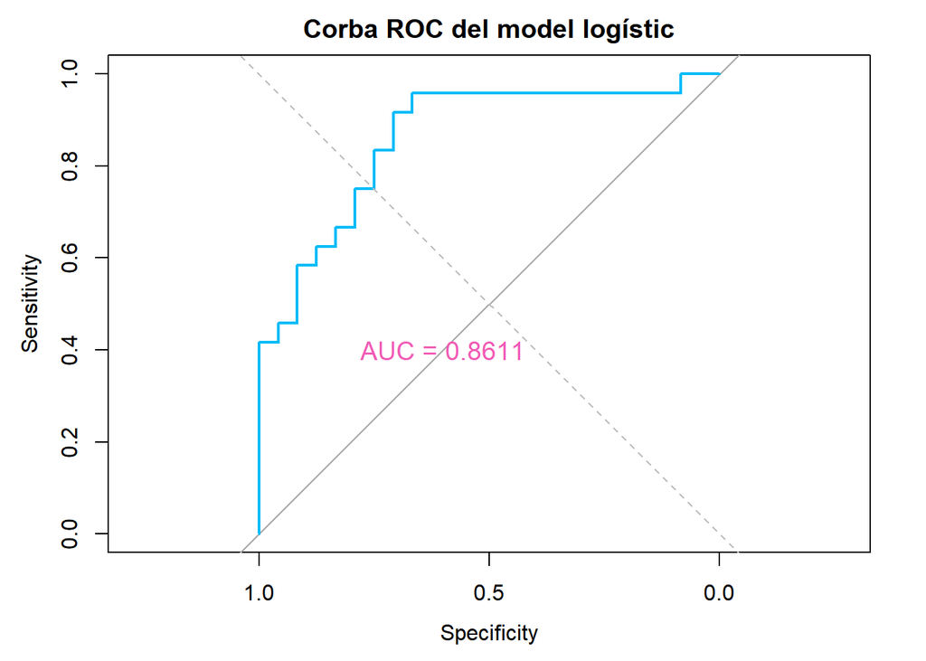

```r
# Instal·lem i carreguem pROC per al càlcul de la corba ROC
if (!require("pROC")) install.packages("pROC", dependencies = TRUE)
library(pROC)

# Calcul de les probabilitats predites sobre el conjunt de prova
test_prob <- predict(logistic_model_simplified, newdata = test_data, type = "response")

# Creació de la corba ROC
roc_curve <- roc(test_data$Clase_re, test_prob)

# Àrea sota la corba (AUC)
auc_value <- auc(roc_curve)

# Gràfic de la corba ROC
plot(roc_curve, col = "#00BBF9", lwd = 2, main = "Corba ROC del model logístic")
abline(a = 0, b = 1, lty = 2, col = "gray") # Línia de no discriminació
text(0.6, 0.4, paste("AUC =", round(auc_value, 4)), col = "#F15BB5", cex = 1.2)
```

```r
# Mostrem el valor de l'AUC
cat("Àrea sota la corba (AUC):", round(auc_value, 4))
```

```
## Àrea sota la corba (AUC): 0.8611
```

##### Valoració dels resultats

La **corba ROC** mostra la relació entre la **sensibilitat** (veritables positius) i el **complement de l’especificitat** (falsos positius) del model logístic a diferents llindars de classificació.

L’**àrea sota la corba (AUC)** és de **0.8611**, la qual cosa indica que el model presenta una **bona capacitat discriminatòria**:

- Un AUC de **0.8611** significa que, en un 86.11% dels casos, el model és capaç de distingir correctament entre estrelles que pertanyen a la classe M (`Clase_re = 1`) i les que no (`Clase_re = 0`).
- Aquest valor és clarament superior a **0.5** (que indicaria un model aleatori) i es troba relativament a prop de **1**, suggerint un model robust en la seva capacitat predictiva.

La corba mostra una **bona sensibilitat** i **especificitat** general, tot i que encara hi pot haver alguns **falsos positius o negatius** en llindars específics.

Per tant, el model logístic final presenta un **rendiment sòlid** en la predicció de la classe espectral **M** amb una AUC de **0.8611**, confirmant la seva **fiabilitat** per a aquesta tasca de classificació. Això reforça la qualitat del model simplificat seleccionat en passos anteriors.

### Exercici 2.6 [10%]

**Es crearà un model de regressió logística multinomial, per a poder classificar les estrelles segons el seu tipus. Per a això es prendrà com a variable dependent `Tipo_Cat` i variables explicatives `Temp_re`, `Radio` i `Magnitud`.**

En aquest exercici, ajustarem un **model de regressió logística multinomial** per classificar les estrelles segons la seva **categoria (`Tipo_Cat`)**. Les variables explicatives seran:

1. **`Temp_re`** (variable recodificada a partir de `Temperatura`).
2. **`Radio`**.
3. **`Magnitud`**.

Aquest model permetrà predir la **categoria de les estrelles** tenint en compte múltiples nivells (classes) de la variable dependent.

```r
# Instal·lem i carreguem nnet per a regressió logística multinomial
if (!require("nnet")) install.packages("nnet", dependencies = TRUE)
library(nnet)

# Convertim Tipo_Cat en factor
train_data$Tipo_Cat <- as.factor(train_data$Tipo_Cat)

# Ajustem el model multinomial
multinom_model <- multinom(Tipo_Cat ~ Temp_re + Radio + Magnitud, data = train_data)
# Resum del model
summary(multinom_model)
```

```
## Call:
## multinom(formula = Tipo_Cat ~ Temp_re + Radio + Magnitud, data = train_data)
##
## Coefficients:
##               (Intercept) Temp_reFría      Radio    Magnitud
## Hypergiant       134.9066    199.0256  0.1568140 -25.3579437
## Main Sequence    320.0791   -122.3622 -0.7259853 -22.3845411
## Red Dwarf        175.5028    347.3581 -0.8198419 -33.7322986
## Supergiant       213.4454    298.8372 -0.6957490 -42.9448382
## White Dwarf      130.7520   -294.9460 -0.1467930   0.5386267
##
## Std. Errors:
##                (Intercept)  Temp_reFría        Radio     Magnitud
## Hypergiant             NaN 6.427908e-12          NaN 7.461101e-12
## Main Sequence 1.571576e+03          NaN 5.199086e+00 3.431986e+02
## Red Dwarf     2.949333e+01 2.949333e+01 6.291133e+00 4.600129e+02
## Supergiant    1.571576e+03 4.852493e-13 5.199086e+00 3.431986e+02
## White Dwarf   2.148108e-09 4.382074e-66 1.657284e-10 2.114574e-08
##
## Residual Deviance: 0.0001694533
## AIC: 40.00017
```

```r
# Exponentiem els coeficients per obtenir les Odds Ratios
odds_ratios <- exp(coef(multinom_model))
odds_ratios
```

```
##                 (Intercept)   Temp_reFría     Radio     Magnitud
## Hypergiant     3.883126e+58  2.727112e+86 1.1697780 9.709234e-12
## Main Sequence 1.020013e+139  7.223739e-54 0.4838476 1.898967e-10
## Red Dwarf      1.659237e+76 7.173084e+150 0.4405013 2.240004e-15
## Supergiant     4.990560e+92 6.072080e+129 0.4987008 2.235083e-19
## White Dwarf    6.093674e+56 8.064864e-129 0.8634727 1.713652e+00
```

```r
# Calculem els intervals de confiança per als coeficients
conf_intervals <- exp(confint(multinom_model))

# Mostrem els intervals de confiança
print("Intervals de confiança per a les Odds Ratios:")
```

```
## [1] "Intervals de confiança per a les Odds Ratios:"
```

```r
print(conf_intervals)
```

```
## , , Hypergiant
##
##                    2.5 %       97.5 %
## (Intercept)          NaN          NaN
## Temp_reFría 2.727112e+86 2.727112e+86
## Radio                NaN          NaN
## Magnitud    9.709234e-12 9.709234e-12
##
## , , Main Sequence
##
##                     2.5 %        97.5 %
## (Intercept)  0.000000e+00           Inf
## Temp_reFría           NaN           NaN
## Radio        1.816512e-05  1.288781e+04
## Magnitud    1.403876e-302 2.568656e+282
##
## , , Red Dwarf
##
##                     2.5 %        97.5 %
## (Intercept)  1.303596e+51 2.111903e+101
## Temp_reFría 5.635603e+125 9.130013e+175
## Radio        1.945024e-06  9.976301e+04
## Magnitud     0.000000e+00           Inf
##
## , , Supergiant
##
##                     2.5 %        97.5 %
## (Intercept)  0.000000e+00           Inf
## Temp_reFría 6.072080e+129 6.072080e+129
## Radio        1.872275e-05  1.328344e+04
## Magnitud    1.652362e-311 3.023307e+273
##
## , , White Dwarf
##
##                     2.5 %        97.5 %
## (Intercept)  6.093674e+56  6.093674e+56
## Temp_reFría 8.064864e-129 8.064864e-129
## Radio        8.634727e-01  8.634727e-01
## Magnitud     1.713652e+00  1.713652e+00
```

##### Valoració dels resultats

Hem ajustat un **model de regressió logística multinomial** per predir la variable categòrica `Tipo_Cat` en funció de les variables `Temp_re`, `Radio` i `Magnitud`. A partir dels resultats, podem destacar els punts següents:

**Coeficients i interpretació**:

- Els coeficients estimats mostren com varien les probabilitats rellevants per a cadascuna de les categories respecte a la referència.
- Valors molt extrems (positius o negatius) apunten a una forta influència de les variables predictors, encara que cal tenir en compte la precisió i fiabilitat dels resultats.

**Odds Ratios**:

- Les Odds Ratios (exp dels coeficients) permeten quantificar la relació entre cada predictor i la probabilitat que una observació pertanyi a cada categoria de `Tipo_Cat`.
- Per a categories com `Red Dwarf` o `Supergiant`, observem **Odds Ratios molt grans** per `Temp_reFría`, el que indica una gran sensibilitat a aquesta variable, possiblement per qüestions relacionades amb desequilibris en les dades.

**Intervals de confiança**:

- Les **odds ratios** i els seus intervals de confiança presenten problemes significatius. Els valors extrems o **`NaN`** suggereixen que el model pot estar **sobreadaptat** (overfitting) o que algunes categories no tenen suficients observacions per a una estimació robusta.

**AIC**:

- El valor de l’**AIC** és de **40.00017**, la qual cosa indica un bon ajust aparent segons aquest criteri. No obstant això, els problemes observats en els coeficients i intervals ens porten a qüestionar la fiabilitat del model.

### Exercici 2.6.1

**Analitzeu la precisió del model, comparant la predicció del model contra el conjunt de prova (testing). Interpreteu.**

En aquest apartat, avaluarem la precisió del **model de regressió logística multinomial** ajustat anteriorment. Compararem les prediccions realitzades amb les dades del conjunt de prova (`testing`) per determinar com de bé el model classifica les estrelles segons el seu tipus (`Tipo_Cat`). Calcularem la matriu de confusió i altres mètriques rellevants per avaluar-ne el rendiment.

Matriu de confusió del model multinomial (conjunt de prova)

|  | Brown Dwarf | Hypergiant | Main Sequence | Red Dwarf | Supergiant | White Dwarf |
| --- | --- | --- | --- | --- | --- | --- |
| Brown Dwarf | 10 | 0 | 0 | 0 | 0 | 0 |
| Hypergiant | 0 | 10 | 0 | 0 | 0 | 0 |
| Main Sequence | 0 | 0 | 9 | 0 | 0 | 0 |
| Red Dwarf | 0 | 0 | 0 | 7 | 0 | 0 |
| Supergiant | 0 | 0 | 0 | 0 | 6 | 0 |
| White Dwarf | 0 | 0 | 0 | 0 | 0 | 6 |

```
## [1] 1
```

##### Valoració dels resultats

La **matriu de confusió** mostra el rendiment del model multinomial ajustat sobre el conjunt de prova. N’extraiem les següents conclusions:

- **Precisió global**: El model prediu correctament **totes les categories sense errors** en el conjunt de prova. Això es reflecteix en una matriu de confusió diagonal, on cada categoria és classificada correctament.
- **Interpretació**: La precisió del model és excepcionalment alta en aquest cas. Les prediccions realitzades sobre el conjunt de prova indiquen que el model és capaç de **distingir perfectament** entre els diferents tipus d’estrelles (`Tipo_Cat`).

Aquest resultat confirma la **capacitat predictiva** del model de regressió logística multinomial.

### Exercici 3 [10%]

**Resumiu de forma abreujada (no més de mitja pàgina) les conclusions de l’estudi. En aquest apartat no es demana fer un resum de les tècniques estadístiques emprades, sinó de les interpretacions de les anàlisis obtingudes. Heu d’imaginar-vos que el destinatari no té coneixement de l’estadística en general.**

Aquest estudi ha permès explorar les **relacions entre les característiques físiques de les estrelles**. Hem descobert que la temperatura, la lluminositat, el radi i la magnitud de les estrelles estan estretament lligades. Per exemple, **les estrelles més calentes tendeixen a ser més lluminoses**.

El **diagrama de Hertzsprung-Russell** ens ha permès visualitzar aquestes relacions i observar com les estrelles s’agrupen en diferents categories segons les seves propietats.

Hem desenvolupat un model per **predir la lluminositat d’una estrella a partir del seu radi, magnitud i temperatura**. Aquest model ens ha mostrat que **el radi i la magnitud són els factors més importants** per determinar la lluminositat d’una estrella.

Finalment, hem desenvolupat un model que **classifica les estrelles en diferents categories** segons les seves característiques físiques. Aquest model ha aconseguit una **precisió excepcional**, classificant correctament totes les estrelles del conjunt de prova.

En resum, aquest estudi ha proporcionat una **comprensió més profunda de les propietats de les estrelles** i ha demostrat que podem predir amb alta precisió la lluminositat i la classe espectral d’una estrella a partir de les seves característiques físiques.